# --force ./buildyou

rm -rf doubt · the della effect, rebuilt · no platform credits · your keys, your ollama, your dolls

47 apps shipped · 6 sisters · 1 tree · 0 credits needed

## ❯ the 6-week buildyou protocol

six weeks. six commands. one you. post 3 tiles a week — rows land top-to-bottom on your profile. della is small now: she hides in the grid, she doesn't run it.

### ❯ find the grid bandit

della hides in one tile. tap tiles to find her. she moves every time you catch her.

caught: 0

### ❯ quotes — tap to copy

tap any quote to copy it for a post.

## ❯ the sisters

six sisters, sealed for Halloween. same height, same scale, every one of them means something. your added dolls join as guests — canon stays clean.

[figure not shown]

### ❯ add a doll

she joins as a guest doll — the six canon sisters stay sealed. she lives in this browser until you delete her.

name made of her struggle personality energy — one line picture (optional)

## ❯ tree room splitter

the enchanted tree, sliced level by level. slide down from the canopy to the void — every level has its rooms, and every room has its keeper.

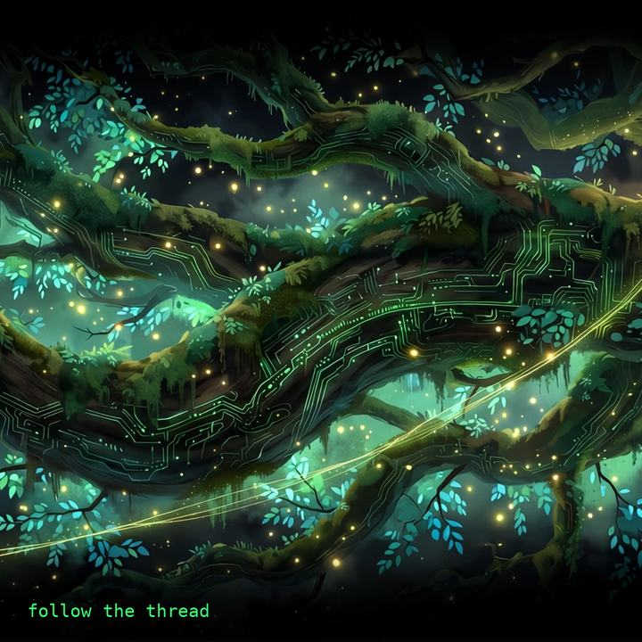

### ❯ whisper's seven rooms

she keeps them all — and holds the other dolls' heavy things in them. she does NOT haunt; she is home.

## ❯ lore infuser

progress: **0 of 5 read** · follow **@creativefactory.studio** — new chapters drop there first.

### ❯ infuse — write what happens next

uses the ai router (your keys first, ollama if they fail) to continue the story from where you left off — in your voice, inside canon. pick the episode it continues from:

one spark (optional — a word, a room, a sister)

no infusion yet — pick an episode and press infuse.

## ❯ ai studio — your keys, your ollama

no platform credits. the router tries your gemini keys in order, rotates when one hits its limit, and falls back to ollama on your phone. it always tells you which engine answered.

checking engines…

### ❯ chat — brand voice

brand voice active · lowercase · terminal-forest · --force ./buildyou

### ❯ caption maker

describe the tile, get a caption in your voice.

### ❯ image — gemini flash image

describe the image. needs a cloud key — ollama can't draw, and the page will say so instead of pretending.

### ❯ keys & engines — settings

keys live only in this browser's storage. they are sent to google, nowhere else. add a second key and the router rotates when the first hits its limit — free keys come from google ai studio.

gemini keys (one per line)

ollama url ollama model

**task routing**

chat → gemini 2.5 flash · caption → gemini 2.5 flash · lore → gemini 2.5 flash · image → gemini 2.5 flash image

every text task falls back to ollama when all keys fail. image has no local fallback — the page says so.